# Analysis and quantification of mass spectrometry imaging data

Dr Matt Smith

6th October 2023

# Load packages and functions

```r
library(quantMSImageR)
library(Cardinal)
library(dplyr)
library(chemCal)

#.libPaths()

# Set paths
base_path = "C:/Users/matsmi/OneDrive - Karolinska Institutet/Dokument/MSI/quantMSImageR"
#base_path = "C:MSI/quant_MSImageR"
data_path = "C:/Users/matsmi/OneDrive - Karolinska Institutet/Dokument/MSI/quantMSImageR/data"
#data_path = "C:MSI/quant_MSImageR/data"
out_path = "C:/Users/matsmi/OneDrive - Karolinska Institutet/Dokument/MSI/quantMSImageR/results"
#out_path = "C:MSI/quant_MSImageR/results"
```

# Load files

Read imzML mass spectrometry imaging data files into R, using Cardinal package and generate ion images to view the data.

```r
cal_mix = Cardinal::readImzML(name = "2021_05_26_6_mix_dil_slide-01_02_50um_pos_1",
                              folder = data_path)
tissue = Cardinal::readImzML(name = "2120_05_27_Cassettedosed_Liver_2Hrs_MRM01_1",
                             folder = data_path)
```

## Set common m/z axis

Set a common m/z axis for each data file, to enable merging of the data downstream. This can be loaded from a .csv file with fixed headers as shown.

### Calibration MSI data

```r
# Import mz_axes df (including IS info)
mz_df = read.csv(sprintf("%s/mz_axes.csv",data_path))
mz_df
```

```
##     cal_mzs tissue_mzs analyte mz_name
## 1  260.0000   299.0000 analyte       1
## 2  287.4840   315.6856 analyte       2
## 3  317.8732   333.3024 analyte       3
## 4  351.4748   351.9023 analyte       4
## 5  388.6284   371.5402 analyte       5
## 6  429.7093   392.2739 analyte       6
## 7  475.1328   414.1647 analyte       7
## 8  525.3580   437.2770 analyte       8
## 9  580.8923   461.6792 analyte       9
## 10 642.2970   487.4431 analyte      10
## 11 710.1927   514.6448 analyte      11
## 12 785.2654   543.3645 analyte      12
## 13       NA   573.6868 analyte      13
## 14       NA   605.7013 analyte      14
## 15       NA   639.5024 analyte      15
## 16       NA   675.1897 analyte      16
## 17       NA   712.8685 analyte      17
## 18       NA   752.6500 analyte      18
## 19       NA   794.6515 analyte      19
```

```r
cal_matrix = as.matrix(spectra(cal_mix))
cal_matrix = rbind(cal_matrix,
                   matrix(ncol = ncol(cal_matrix),
                          nrow = nrow(mz_df) - nrow(cal_matrix)))

cal_mix = MSImagingExperiment(imageData=cal_matrix,
                           featureData=MassDataFrame(mz=mz_df$mz_name,
                                                     analyte = mz_df$analyte,
                                                     cal_mz = as.numeric(mz_df$cal_mzs)),
                           pixelData=pData(cal_mix))
```

### Tissue MSI data

```r
tissue_matrix = as.matrix(spectra(tissue))
tissue_matrix = rbind(tissue_matrix,
                   matrix(ncol = ncol(tissue_matrix),
                          nrow = nrow(mz_df) - nrow(tissue_matrix)))

tissue = MSImagingExperiment(imageData=tissue_matrix,
                           featureData=MassDataFrame(mz=mz_df$mz_name,
                                                     analyte = mz_df$analyte,
                                                     tissue_mz = as.numeric(mz_df$tissue_mzs)),
                           pixelData=pData(tissue))
```

# Set regions of interest (ROIs)

Select ROIs in each MSI dataset.

## Select calibration spikes

For each spot select the entire area, such that the amount of standard can be divided by number of pixels to determine the average amount per pixel. If standard addition approach to be used, create an additional ROI on the surface away form the calibration spikes.

```r
# Set ROIs around calibration levels
cal_roi_df = read.csv(sprintf("%s/cal_rois.csv",data_path))

# Set cal levels
#cal1 <- selectROI(cal_mix, mz = mz(cal_mix)[1], contrast.enhance="histogram")
cal1 = cal_roi_df$cal1
#image(cal_mix, cal1~x*y, key=T)

#cal2 <- selectROI(cal_mix, mz = mz(cal_mix)[1], contrast.enhance="histogram")
cal2 = cal_roi_df$cal2
#image(cal_mix, cal2~x*y, key=T)

#cal3 <- selectROI(cal_mix, mz = mz(cal_mix)[1], contrast.enhance="histogram")
cal3 = cal_roi_df$cal3
#image(cal_mix, cal3~x*y, key=T)

#cal4 <- selectROI(cal_mix, mz = mz(cal_mix)[1], contrast.enhance="histogram")
cal4 = cal_roi_df$cal4
#image(cal_mix, cal4~x*y, key=T)

#cal5 <- selectROI(cal_mix, mz = mz(cal_mix)[2], contrast.enhance="histogram")
cal5 = cal_roi_df$cal5
#image(cal_mix, cal5~x*y, key=T)

#cal6 <- selectROI(cal_mix, mz = mz(cal_mix)[2], contrast.enhance="histogram")
cal6 = cal_roi_df$cal6
#image(cal_mix, cal6~x*y, key=T)

# Away from cal mix for standard addition - background
#cal7 <- selectROI(cal_mix, mz = mz(cal_mix)[1], contrast.enhance="histogram")
cal7 = cal_roi_df$cal7
#image(cal_mix, cal7~x*y, key=T)

cal_levels = makeFactor(L1 = cal1, L2 = cal2, L3 = cal3,
           L4 = cal4, L5 = cal5, L6 = cal6, L7 = cal7)

# Update pixel metadata
pData(cal_mix)$sample_type = "Cal"
pData(cal_mix)$replicate = "01"
pData(cal_mix)$ROI = cal_levels
pData(cal_mix)$sample_ID = sprintf("%s_rep%s_%s", pData(cal_mix)$sample_type, pData(cal_mix)$replicate, pData(cal_mix)$ROI)
pData(cal_mix)
```

```
## PositionDataFrame with 115663 rows and 4 columns
##                                              :run:   coord:x   coord:y
##                                           <factor> <integer> <integer>
## 1      2021_05_26_6_mix_dil_slide-01_02_50um_pos_1         1         1
## 2      2021_05_26_6_mix_dil_slide-01_02_50um_pos_1         2         1
## 3      2021_05_26_6_mix_dil_slide-01_02_50um_pos_1         3         1
## 4      2021_05_26_6_mix_dil_slide-01_02_50um_pos_1         4         1
## 5      2021_05_26_6_mix_dil_slide-01_02_50um_pos_1         5         1
## ...                                            ...       ...       ...
## 115659 2021_05_26_6_mix_dil_slide-01_02_50um_pos_1       951       121
## 115660 2021_05_26_6_mix_dil_slide-01_02_50um_pos_1       952       121
## 115661 2021_05_26_6_mix_dil_slide-01_02_50um_pos_1       953       121
## 115662 2021_05_26_6_mix_dil_slide-01_02_50um_pos_1       954       121
## 115663 2021_05_26_6_mix_dil_slide-01_02_50um_pos_1       955       121
##        sample_type   replicate      ROI    sample_ID
##        <character> <character> <factor>  <character>
## 1              Cal          01       NA Cal_rep01_NA
## 2              Cal          01       NA Cal_rep01_NA
## 3              Cal          01       NA Cal_rep01_NA
## 4              Cal          01       NA Cal_rep01_NA
## 5              Cal          01       NA Cal_rep01_NA
## ...            ...         ...      ...          ...
## 115659         Cal          01       NA Cal_rep01_NA
## 115660         Cal          01       NA Cal_rep01_NA
## 115661         Cal          01       NA Cal_rep01_NA
## 115662         Cal          01       NA Cal_rep01_NA
## 115663         Cal          01       NA Cal_rep01_NA
```

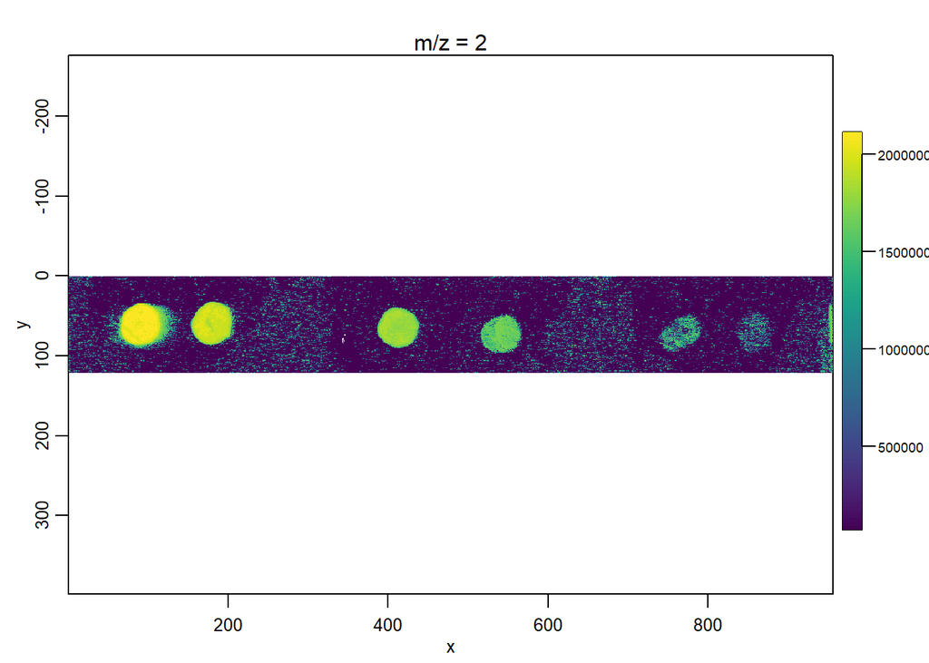

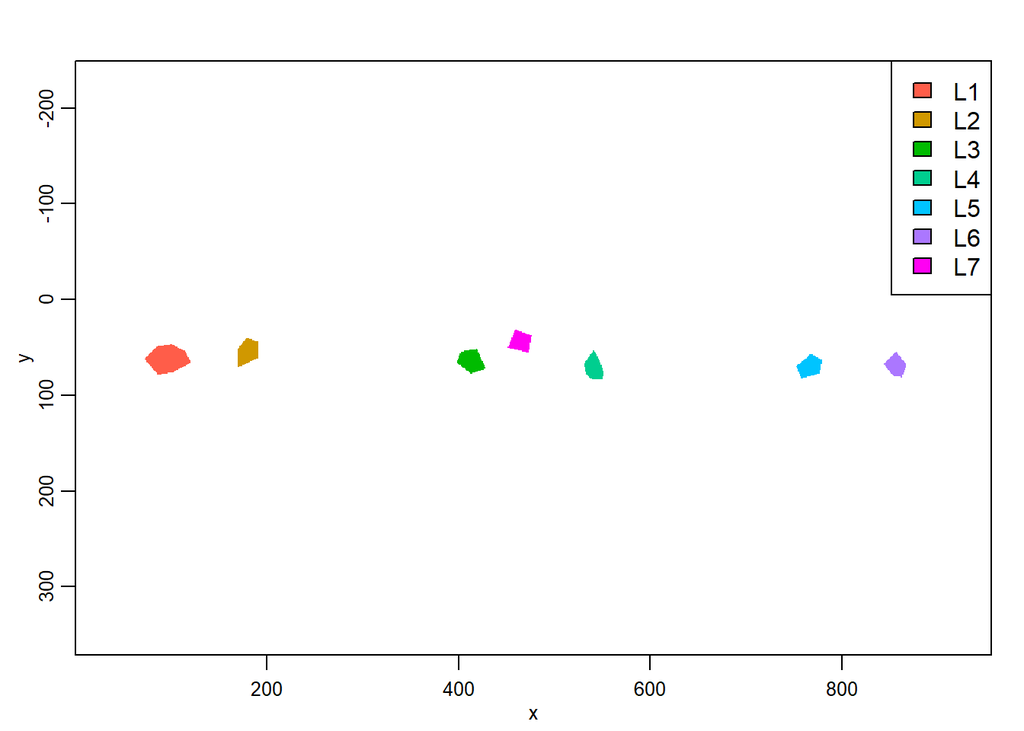

```r
# Image cal mix
image(cal_mix, mz = mz(cal_mix)[2], contrast.enhance="histogram")
image(cal_mix, cal_levels~x*y, key=T)
```

## Subset tissue

Select ROI around the tissue of interest from the MSI dataset.

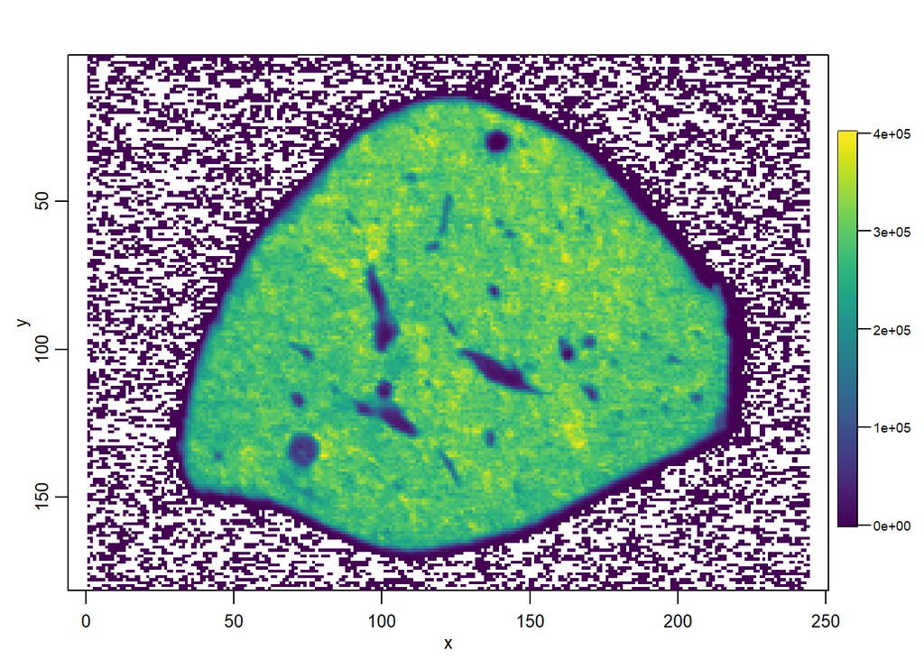

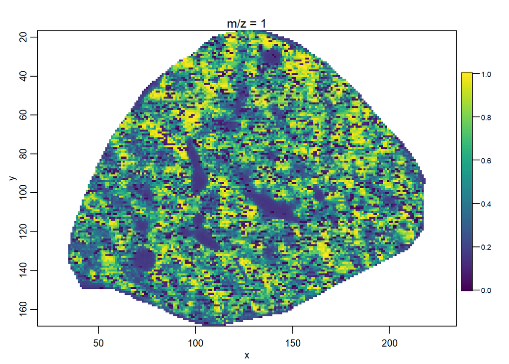

```r
tissue_pixel_df = read.csv(sprintf("%s/tissue_pixels.csv",data_path))

image(tissue)

# Subset tissue pixels
#tissue_pixels = selectROI(tissue, contrast.enhance="histogram")
tissue_pixels = tissue_pixel_df$tissue_pixels
tissue = tissue[, tissue_pixels]

# Image tissue before and after subsetting
image(tissue, mz = mz(tissue)[1], contrast.enhance="histogram",
      superpose = FALSE, normalize.image = "linear")
```

### Select tissue ROIs

In the subset tissue, select ROIs relating to distinct spatial regions (e.g cell types).

```r
tissue_roi_df = read.csv(sprintf("%s/tissue_rois.csv",data_path))

#tissue_roi1 <- selectROI(tissue, mz = mz(tissue)[2], contrast.enhance="histogram")
tissue_roi1 = tissue_roi_df$tissue_roi1
#image(tissue, tissue_roi1~x*y, key=T)

#tissue_roi2 <- selectROI(tissue, mz = mz(tissue)[2], contrast.enhance="histogram")
tissue_roi2 = tissue_roi_df$tissue_roi2
#image(tissue, tissue_roi2~x*y, key=T)

#tissue_roi3 <- selectROI(tissue, mz = mz(tissue)[2], contrast.enhance="histogram")
tissue_roi3 = tissue_roi_df$tissue_roi3
#image(tissue, tissue_roi3~x*y, key=T)

#tissue_roi4 <- selectROI(tissue, mz = mz(tissue)[2], contrast.enhance="histogram")
tissue_roi4 = tissue_roi_df$tissue_roi4
#image(tissue, tissue_roi4~x*y, key=T)

#tissue_roi5 <- selectROI(tissue, mz = mz(tissue)[2], contrast.enhance="histogram")
tissue_roi5 = tissue_roi_df$tissue_roi5
#image(tissue, tissue_roi5~x*y, key=T)

#tissue_roi6 <- selectROI(tissue, mz = mz(tissue)[2], contrast.enhance="histogram")
tissue_roi6 = tissue_roi_df$tissue_roi6
#image(tissue, tissue_roi6~x*y, key=T)

tissue_rois = makeFactor(roi1 = tissue_roi1, roi2 = tissue_roi2, roi3 = tissue_roi3,
                        roi4 = tissue_roi4, roi5 = tissue_roi5, roi6 = tissue_roi6)

# Update pixel metadata
pData(tissue)$sample_type = "Tissue"
pData(tissue)$replicate = "01"
pData(tissue)$ROI = tissue_rois
pData(tissue)$sample_ID = sprintf("%s_rep%s_%s", pData(tissue)$sample_type, pData(tissue)$replicate, pData(tissue)$ROI)
pData(tissue)
```

```
## PositionDataFrame with 19499 rows and 4 columns
##                                             :run:   coord:x   coord:y
##                                          <factor> <integer> <integer>
## 1     2120_05_27_Cassettedosed_Liver_2Hrs_MRM01_1       121        17
## 2     2120_05_27_Cassettedosed_Liver_2Hrs_MRM01_1       122        17
## 3     2120_05_27_Cassettedosed_Liver_2Hrs_MRM01_1       123        17
## 4     2120_05_27_Cassettedosed_Liver_2Hrs_MRM01_1       124        17
## 5     2120_05_27_Cassettedosed_Liver_2Hrs_MRM01_1       125        17
## ...                                           ...       ...       ...
## 19495 2120_05_27_Cassettedosed_Liver_2Hrs_MRM01_1       111       168
## 19496 2120_05_27_Cassettedosed_Liver_2Hrs_MRM01_1       112       168
## 19497 2120_05_27_Cassettedosed_Liver_2Hrs_MRM01_1       113       168
## 19498 2120_05_27_Cassettedosed_Liver_2Hrs_MRM01_1       114       168
## 19499 2120_05_27_Cassettedosed_Liver_2Hrs_MRM01_1       115       168
##       sample_type   replicate      ROI       sample_ID
##       <character> <character> <factor>     <character>
## 1          Tissue          01       NA Tissue_rep01_NA
## 2          Tissue          01       NA Tissue_rep01_NA
## 3          Tissue          01       NA Tissue_rep01_NA
## 4          Tissue          01       NA Tissue_rep01_NA
## 5          Tissue          01       NA Tissue_rep01_NA
## ...           ...         ...      ...             ...
## 19495      Tissue          01       NA Tissue_rep01_NA
## 19496      Tissue          01       NA Tissue_rep01_NA
## 19497      Tissue          01       NA Tissue_rep01_NA
## 19498      Tissue          01       NA Tissue_rep01_NA
## 19499      Tissue          01       NA Tissue_rep01_NA
```

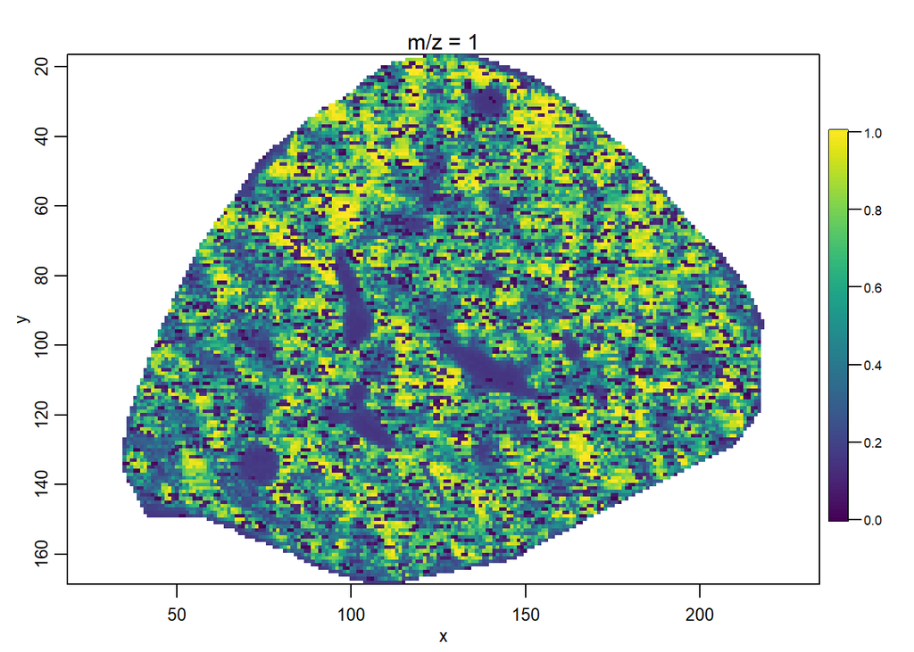

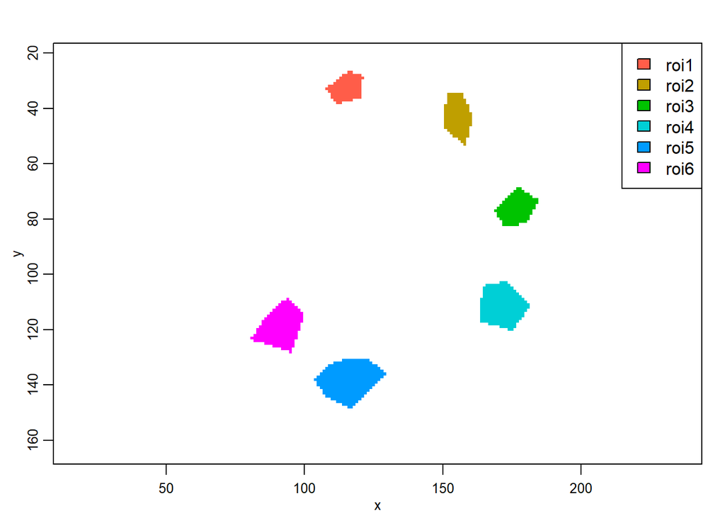

```r
# Image
image(tissue, mz = mz(tissue)[1], contrast.enhance="histogram",
      superpose = FALSE, normalize.image = "linear")
image(tissue, tissue_rois~x*y, key=T)
```